# L07 Scales, Axes & Legends

Data Visualization (STAT 302)

Noah Holubow

## Overview

The goal of this lab is to explore ways to manage and manipulate scales, axes, and legends within `ggplot2`.

## Datasets

We’ll be using the `tech_stocks.rda`, `corruption.rda`, `cdc.txt`, and a few toy datasets.

```r
# Load package(s)
library(tidyverse)

# Load datasets
load("data/tech_stocks.rda")
load("data/corruption.rda")

# Read in the cdc dataset
cdc <- read_delim(file = "data/cdc.txt", delim = "|") %>%
  mutate(genhlth = factor(genhlth,
    levels = c("excellent", "very good", "good", "fair", "poor")
  ))

# Set seed
set.seed(975312468)

# Selecting a random subset of size 100
cdc_small <- cdc %>% slice_sample(n = 100)

# Generating toy datasets for exercise 2
dat1 <- tibble(theta = c(0, 2 * pi))

dat2 <- tibble(
  theta = seq(0, 2 * pi, length.out = 100),
  obs = rnorm(100, sin(theta), 0.1),
  larger_than = ifelse(abs(obs) < abs(sin(theta)), "1", "0")
)
```

## Exercises

Complete the following exercises.

### Exercise 1

Using the `tech_stocks` dataset, recreate the following graphic as precisely as possible.

*Hints:*

- Size of lines in legend is 1.3
- 0.75 and 0.85 will be useful
- Eliminated extra space in horizontal direction
- `key_glyph`

**Answer:**

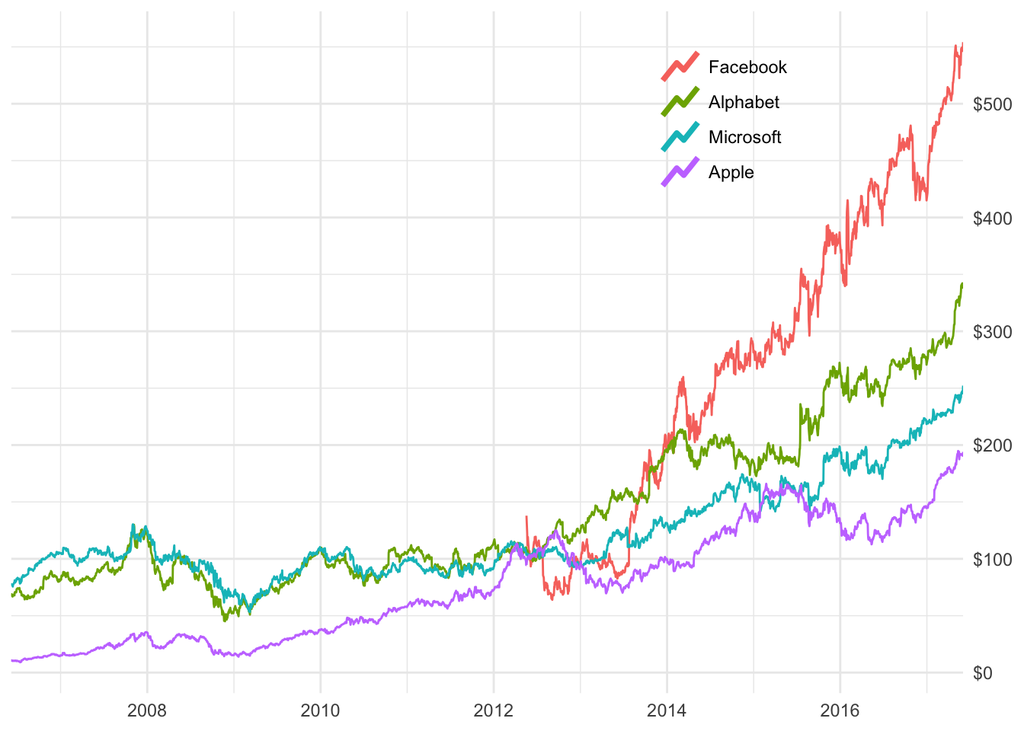

```r
# plot
tech_stocks %>%
  mutate(company = factor(company, levels = c("Facebook", "Alphabet", "Microsoft", "Apple"))) %>% # changing company order
  ggplot(aes(x = date, y = price_indexed)) + # basic plot
  geom_line(aes(color = company), key_glyph = "timeseries") + # plotting trend lines
  guides(color = guide_legend(override.aes = list(size = 1.3))) + # manually changing legend color
  labs(
    x = NULL,
    y = NULL
  ) + # labels
  scale_x_date(expand = c(0,0)) + # setting x-axis scale
  scale_y_continuous(
    position = "right",
    breaks = scales::breaks_width(100),
    labels = scales::label_dollar()) +
  theme_minimal() + # setting y-axis cale
  theme(
    legend.position = c(0.75, 0.85),
    legend.title = element_blank()
    )
```